# Project 5 - Communicate Data Findings - Prosper Loans Dataset

## by Christopher Howells

## Investigation Overview

I wanted to explore the dataset visually and pick out key trends an insights. The main points I will focus on are what the Prosper Loans Score is influenced by and how Borrower APR affects profit indicators.

## Dataset Overview

This dataset looks at loans from 'Prosper', which contains information related to the loan itself (such as amount, term length, expected return) and data on the borrower (such as their credit score limit, prospers rating of them and whether they are a homeowner or employed). There are 113937 rows and 81 columns for the variables which gives us a rich dataset to examine.

## Borrower APR's affect on Estimated Return

I examined how how Borrower APR(interest rate given to the customer) affects profit indicators. I discovered that the higher the Borrower APR is, the higher the lender yeild is, suggesting that any rise in service fee is compensated for by the higher interest. There is a less linear relationship with estimated losses and Borrower APR, however it does look like there is some trend as we would expect the higher APR loans to be given to higher risk customers which would give a bigger overall loss (but this could have just as easily lead to more profit from the higher rate of those performing loans).

Below I visualise the relationship between the Borrower's APR and the Estimated Return:

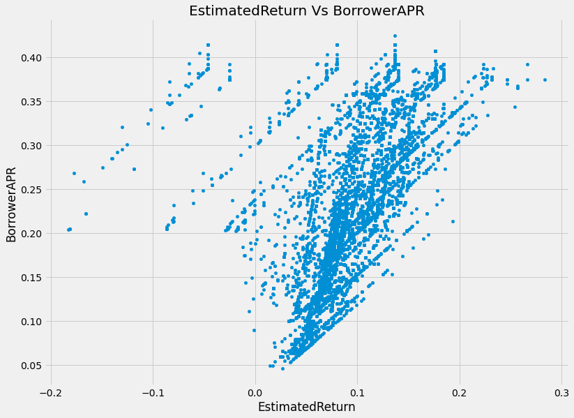

## Correlations with Prosper Rating

We can see below that there is a significant relationship between the Numeric Prosper Rating which is negative with the borrows APR, so the higher the Rating, the lower the APR. This makes sense as the rating is essentially an internal credit rating of how good the borrower is. And so borrows that are more risky with a lower Prosper Rating are given higher Interest rates/APR's to compensate for taking on that risk.

There is a positive correlation with the customers upper credit score range and the Prosper Rating of 0.55 too, showing they are positively correlated suggesting that credit score could play an important role in a customers Prosper Rating.

We can see that the 'loan original amount' is also 0.43 correlated with the Prosper Rating, so perhaps customers with a higher rating are able to borrow more.

Surprsingly Stated Income was barely related suggesting Prosper doesn't consider it relevant or could expect customers to be dishonest in supplying that information.

Borrower APR has a negative correlation with Upper Credit Score again likely as these people are higher risk and so are charged more to borrow by banks.

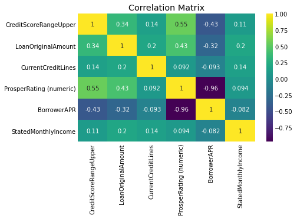

## Prosper Rating, Borrower APR and Employment Status

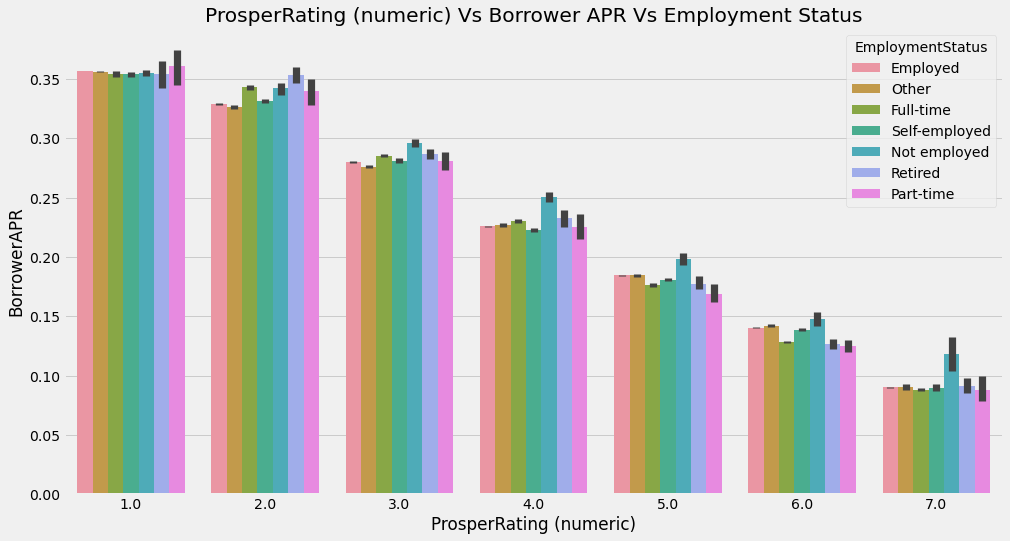

## Prosper Rating, Borrower APR and Homeowner Status

**Below we can see from the stripplot graph showing the density of homeowners Vs non-homeowners that for the lowest Rating's 1 and 2 and higher Borrower APR, there are less red dot density, and therefore less homeowners which would make sense as homeowners are seen as less risky and so would be given a lower score (and pay higehr interest). And at the top end of the scale at 6 and especially 7 we can see from higher density that more are Homeowners which makes sense as we would expect them to be the safest customers with higher incomes and less debt. However throughout the rest of the scale in the middle sections it is not so clear so the other factors (e.g. employment status, credit score etc.) are more important. We can also see the interaction between Borrower APR decreasing with Prosper Rating as the customer is considered less risky.**

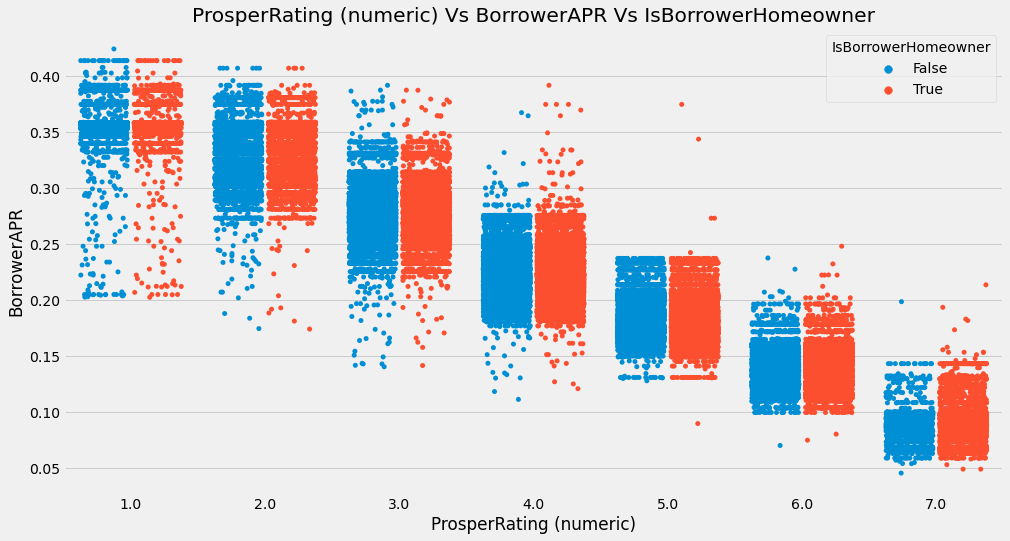

**Thank for you listening!**